# Boxplots Vs Histograms WRT Distributions

mcc

2022-04-06

I was discussing Data Science with a journalist recently, and a question came up;

- Why are Boxplots so important with respect to Exploratory Data Analysis?

Boxplots and histograms are the first tools taught when learning statistical software, but why? **AND**, many online-courses (I’ve seen) gloss over the “*WHY*.”

[Quantile-Quantile plots](https://en.wikipedia.org/wiki/Q%E2%80%93Q_plot) are normally called Q-Q plots.

> For more on Exploratory Data Analysis, I recommend [Exploratory Data Analysis with R](https://leanpub.com/exdata) by Roger Peng, and it’s FREE. Even if you don’t use R (yet) it has some nuggets.

Boxplots, Histrograms, Strip-Charts and Q-Q plots are used to help a statistician visualize three items;

## Skew, Outliers & Kurtosis

1. Skew
   - How symmetrical is *your* distribution.
   - Does the data look even on the left side as it does on the right.
   - First question shold be, Is the data skewed to the left or right or not all?
   - The way I learned skew was by thinking of a duck’s bill.

https://towardsdatascience.com/top-3-methods-for-handling-skewed-data-1334e0debf45

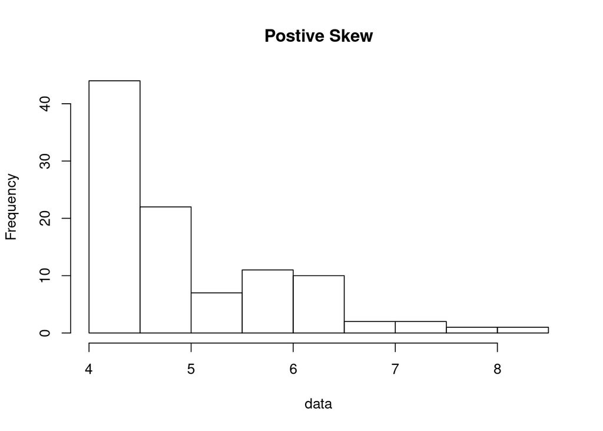

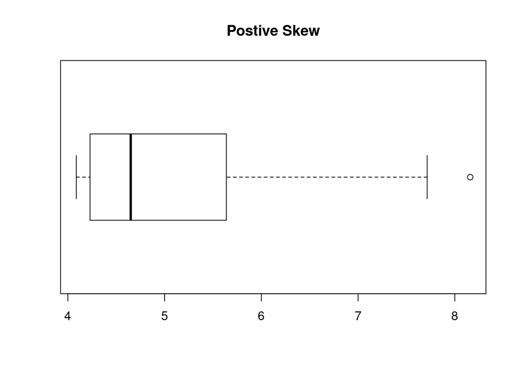

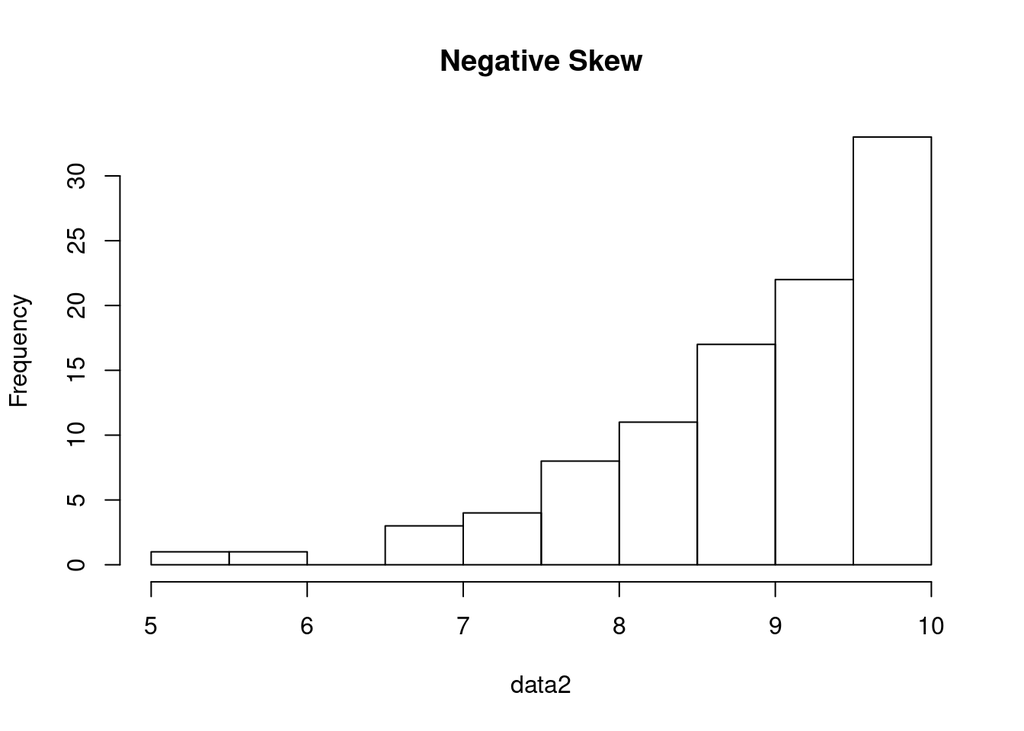

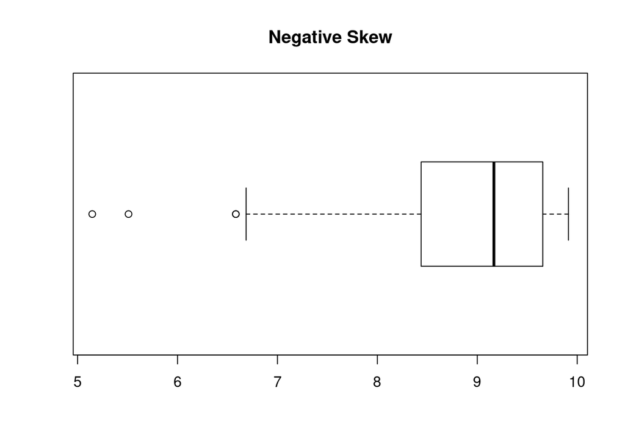

2. Outliers
   - Outliers are outside the arms and whiskers of a boxplot.
3. Kurtosis

Skewness is a measure of symmetry, or we could say the lack of symmetry. A distribution, or data set, is symmetric if it looks the same to the left and right of the center point.

Kurtosis is a measure of whether the data are heavy-tailed or light-tailed relative to a normal distribution. That is, data sets with high kurtosis tend to have heavy tails, or outliers. Data sets with low kurtosis tend to have light tails, or lack of outliers. A uniform distribution would be the extreme case.

## Why carry out an Exploratory Data Analysis?

The major elements of Exploratory Data Analysis can be written out like a check list.

1. Formulate your question(s)
2. Check your data
   - Read in your data
   - Check the data for missing values this mean imputations
   - data structures, for example, numbers converted to strings, categorical data converted to strings, etc.
   - Use the Linux or MacOS command `less`
   - missing commas, or quotes for strings
3. Validate your data with at least one external source
4. Try the easy solution first
5. Challenge your solution
6. Repeat any and all if necessary

Examination of numerical data is useful

Are there outliers missing values Check Boxplots and Histograms

For this article, we will focus on ‘why use Boxplots and Histograms.’

#### Generate a dataset

```r
# Create data
fish <- rpois(200, 5)
guassian <- rnorm(200, mean=10, sd=15)
penny_toss <- rbinom(0:200, 10, 0.33)

print("fish")
```

```
## [1] "fish"
```

```r
print(fish)
```

```
##   [1]  7  4  8  8  5  6  8  8  4  5  6  5  5  8  5  2  5  3  2  3  1  7  4  8  7
##  [26]  2  2  5  8  4  4  2  4  6  2  5  5  7  5  8  4  4  3  5  6 10  7  5  3  4
##  [51]  5  3  5  3  2  5  8  2  4  2  6  7  3  4  5  3  3  6 10  5  4  7  9  6  6
##  [76]  4  6  2  7  7  4  1  8  3  4  5  8  7  5  3  7  7  3  5  2  5  4  4  2  7
## [101]  3  7  3  4  4  2  5  5  7  1  4  7  4  6  3  9  3  3  4  4  7  5  6  6  5
## [126]  6  6  7  6  9  3  7  4  7  3  2  4  8  5  5  2  7  6 10  4  5  6  7  6  3
## [151]  7  6  5  4  6  2  4  6  8  1  3  8  4  4  2  5  8  5  6  8  3  3  8  6  3
## [176]  3 11  2  4  4  7  7  5  4  6  4 11 12  1  8  4  4  8  4  4  4  3  3  6  3
```

```r
print("guassian")
```

```
## [1] "guassian"
```

```r
print(guassian)
```

```
##   [1]  25.42042500  35.74504198  -6.32101225   9.78862769  37.40967457
##   [6]  33.61017024  33.09720005  -3.14206579   3.26842647  19.98945132
##  [11]  18.03666627   4.59897649   1.86906559  32.46246048   9.40748723
##  [16]  33.53370420  17.04586499  17.32975038  19.01338024   4.94416891
##  [21]  25.99763525  -0.04234028   7.41363806  40.43142726  18.62152497
##  [26]  23.36714067  35.11527405   4.35010837 -18.72221931  21.34973360
##  [31]  13.75587016  31.34549167  -1.14337104  -2.65478355  14.00842560
##  [36]  23.75354985  -7.53292703   1.03423770  31.62182765  24.10666408
##  [41] -14.46925851  27.20118990  13.64227566  14.28048792  17.36769947
##  [46]  34.35807570   9.37776438  -9.69699449  -6.22309513  11.83508952
##  [51] -10.34020855 -13.46024879   2.93036121  10.26553238  25.13178897
##  [56]  21.81671059  12.78180802  12.30976471   5.98726542  -1.01445150
##  [61]   8.92808531   3.80376488   3.53855257  -6.77669885  12.22240773
##  [66] -10.58338515  22.99620868  15.88279986   0.06594298   0.54563641
##  [71]  17.20260193   8.93065390   7.91527223  -1.30241505   7.95935240
```

[output cut: 25 more lines]

```r
print("penny_toss")
```

```
## [1] "penny_toss"
```

```r
print(penny_toss)
```

```
##   [1] 6 2 3 4 3 6 3 2 5 4 5 5 3 1 4 2 2 5 2 2 2 3 3 2 5 6 4 4 4 5 5 5 5 3 3 5 4
##  [38] 5 1 3 3 2 1 5 5 2 2 2 7 3 6 4 3 5 3 4 4 3 3 4 6 3 1 1 4 4 2 0 4 3 3 5 3 4
##  [75] 3 4 5 4 7 2 0 2 3 5 4 1 3 2 1 0 3 3 2 4 2 5 5 0 3 2 4 3 2 5 5 3 7 3 2 3 2
## [112] 3 1 8 5 4 3 6 1 6 4 6 3 4 5 5 1 4 4 3 3 3 5 2 4 2 4 3 3 2 5 5 6 2 7 3 3 2
## [149] 1 5 5 5 2 3 2 5 5 4 4 4 2 3 2 3 3 1 1 5 3 4 3 3 4 6 2 4 4 3 3 5 4 2 4 4 4
## [186] 2 2 3 1 4 5 3 4 3 3 2 6 0 4 3 1
```

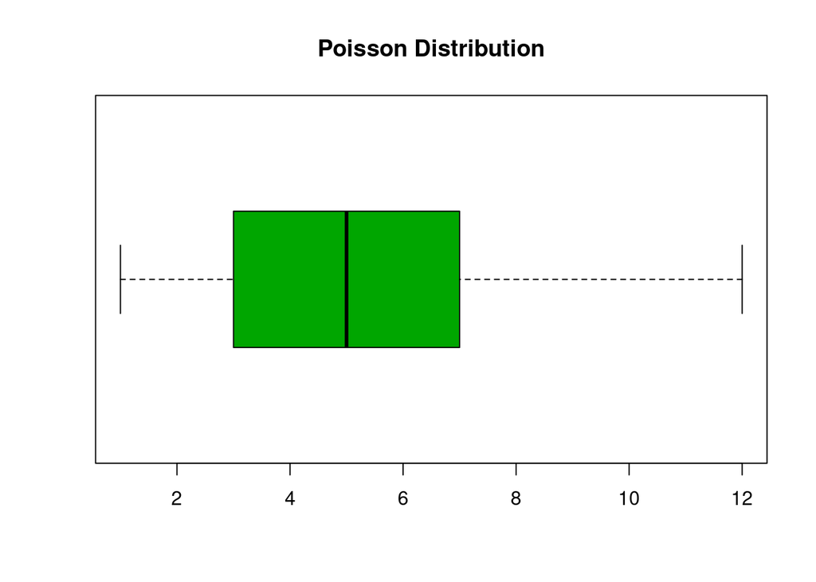

```r
boxplot(fish, col=terrain.colors(4), main="Poisson Distribution", horizontal = T)
```

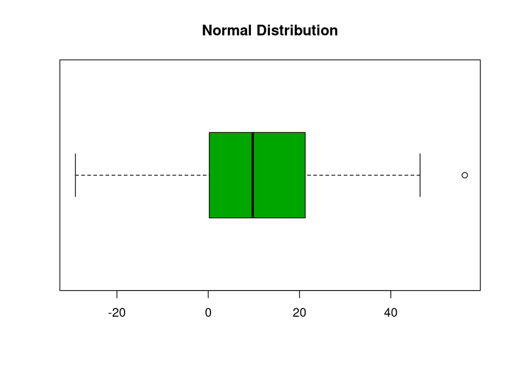

```r
boxplot(guassian, col=terrain.colors(4), main="Normal Distribution", horizontal = T)
```

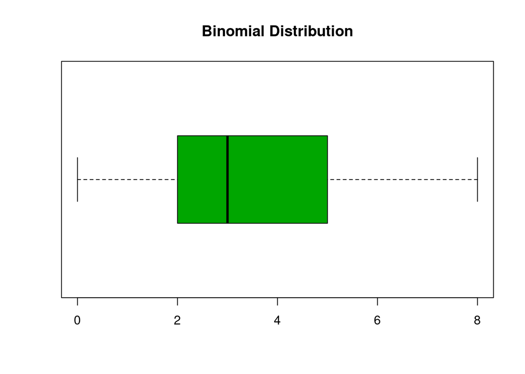

```r
boxplot(penny_toss, col=terrain.colors(4), main="Binomial Distribution", horizontal = T)
```

Histograms

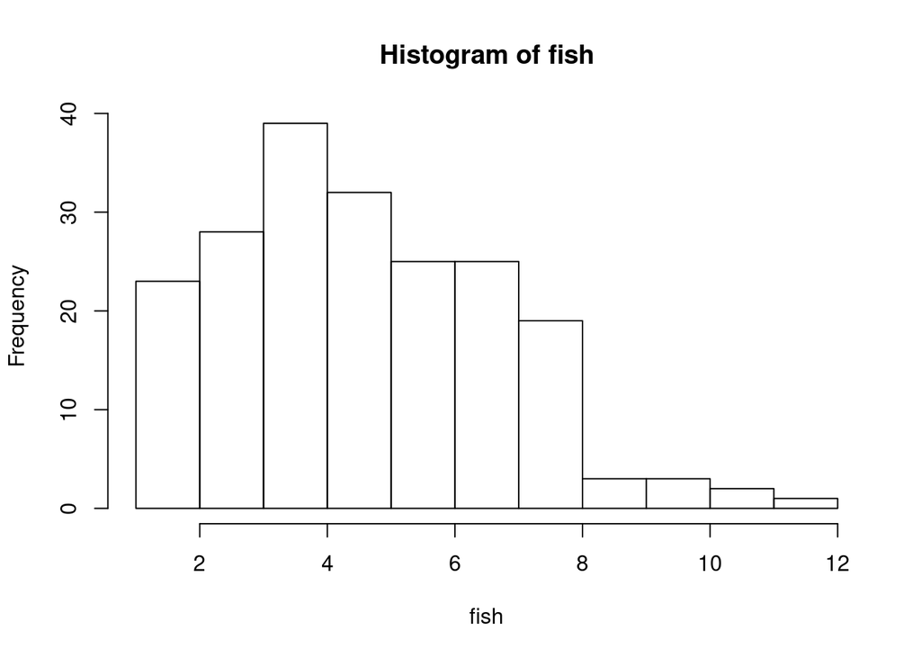

```r
hist(fish)
```

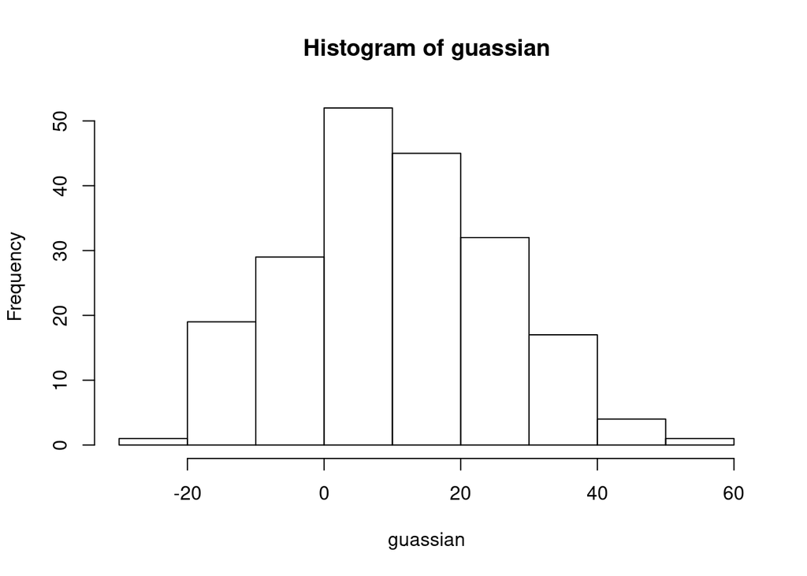

```r
hist(guassian)
```

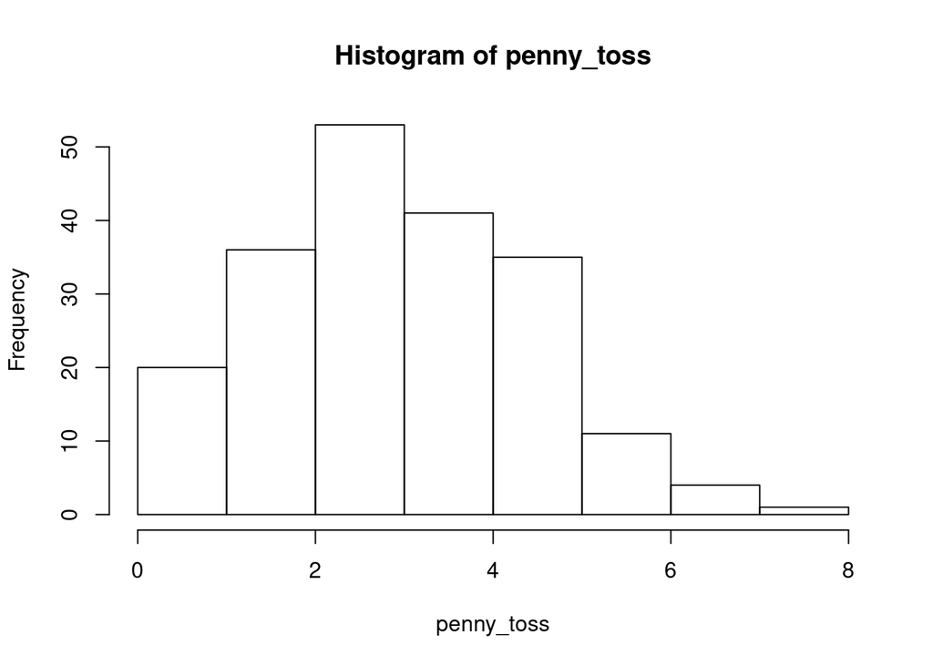

```r
hist(penny_toss)
```

Square Values

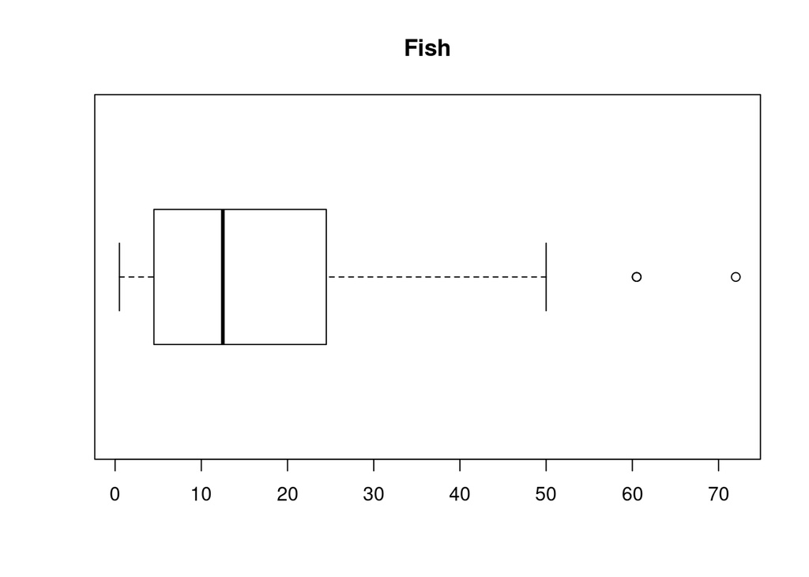

```r
fish_skewed = (1/2)*(fish)^2
guassian_skewed = (1/2)*(guassian)^2
penny_toss_skewed = (1/2)*(penny_toss)^2

boxplot(fish_skewed, main="Fish", horizontal = T)
```

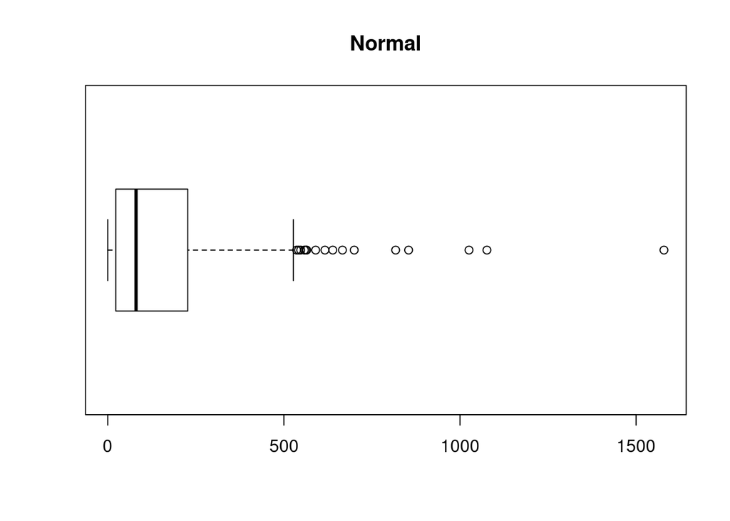

```r
boxplot(guassian_skewed, main="Normal", horizontal = T)
```

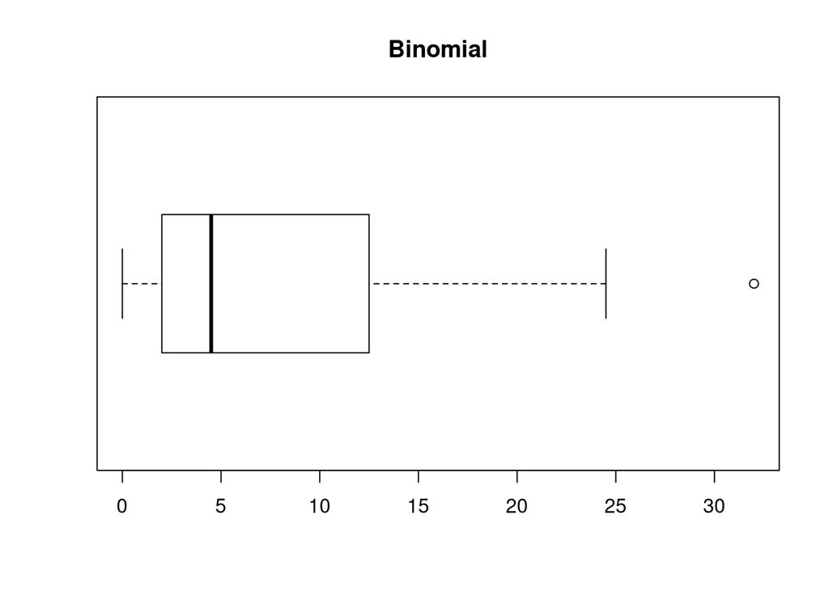

```r
boxplot(penny_toss_skewed, main="Binomial", horizontal = T)
```

Histograms

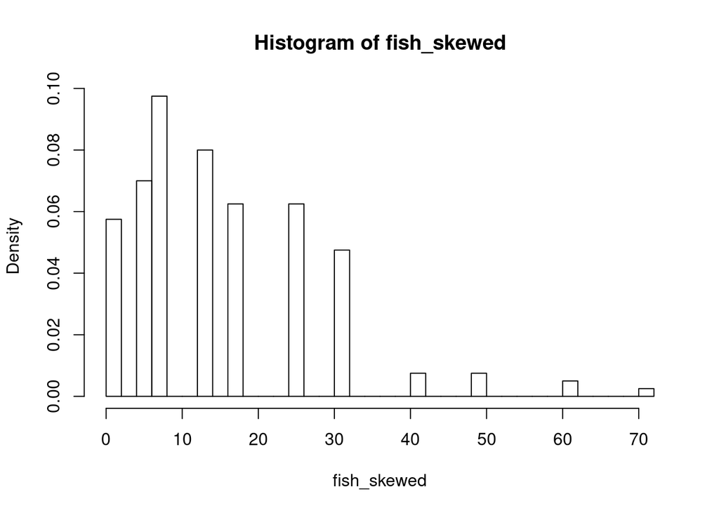

```r
hist(fish_skewed, breaks=50, freq = F)
```

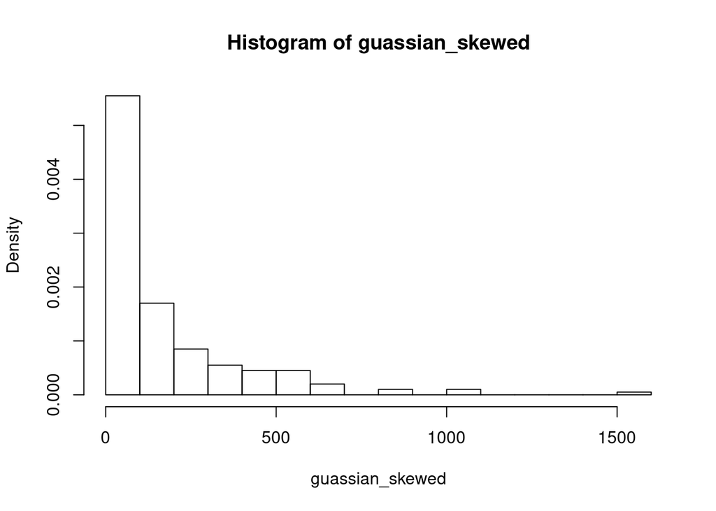

```r
hist(guassian_skewed, breaks=20, freq = F)
```

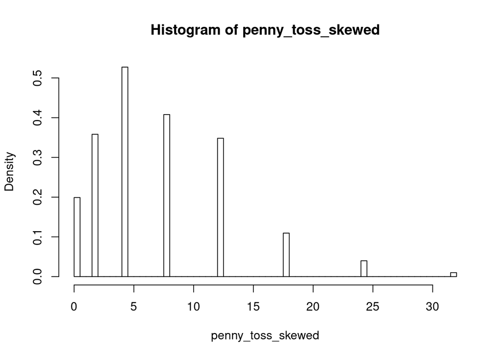

```r
hist(penny_toss_skewed, breaks=50, freq = F)
```

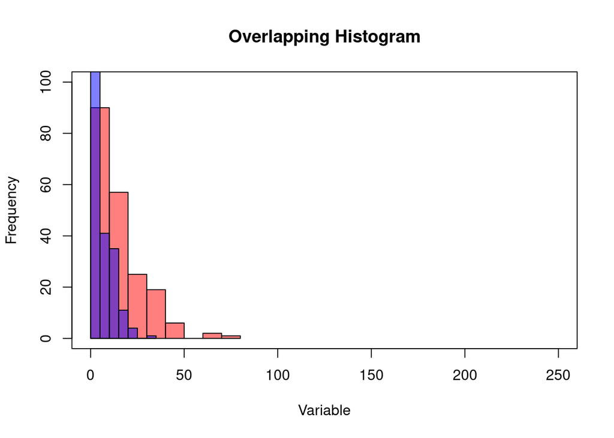

```r
# Histogram Colored (blue and red)
hist(fish_skewed, col=rgb(1,0,0,0.5), xlim=c(0,250), ylim=c(0,100), main="Overlapping Histogram", xlab="Variable")
hist(penny_toss_skewed, col=rgb(0,0,1,0.5), add=T)
box()
```